# Simulation: Two Latent Orderings

Ziang Zhang

## Question and design

Can structural CAVI separate features that follow two different orderings of the same samples? The generator from the [MPCurver feature-partitioning article](https://aguerozz.github.io/MPCurver/articles/partition.html) creates 500 samples, ten quadratic features following ordering A, and ten monotone features following ordering B. Gaussian noise has standard deviation 0.05. The generator seed is 1.

We fit a fixed $M=2$ model with MPCurver 0.3.4, a second-order random-walk prior, $K=50$ grid positions, `ridge = 0`, and Fiedler ordering initialization. The same Fiedler method is applied independently within both similarity-based feature groups. The assignment probabilities are estimated jointly with conditional feature trajectories and sample positions. The fit allows up to 500 temperature-one refinement updates.

## Feature assignments

After aligning the arbitrary A/B labels, the fit assigns all **20 of 20** features to their generating groups (Figure 1).

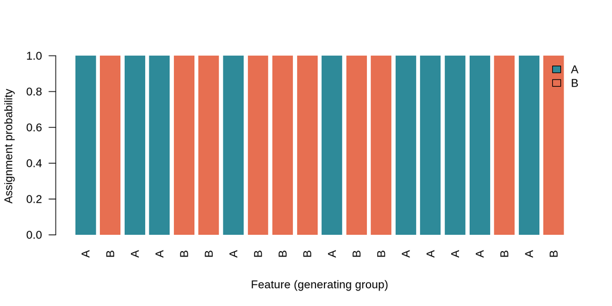

Figure 1. Posterior assignment probabilities for the 20 simulated features. Axis labels show the generating feature group.

## Sample orderings

After aligning ordering labels and allowing reversal of each axis, the absolute Spearman correlations with the two generating positions are **0.9975** and **0.9989** (Figure 2).

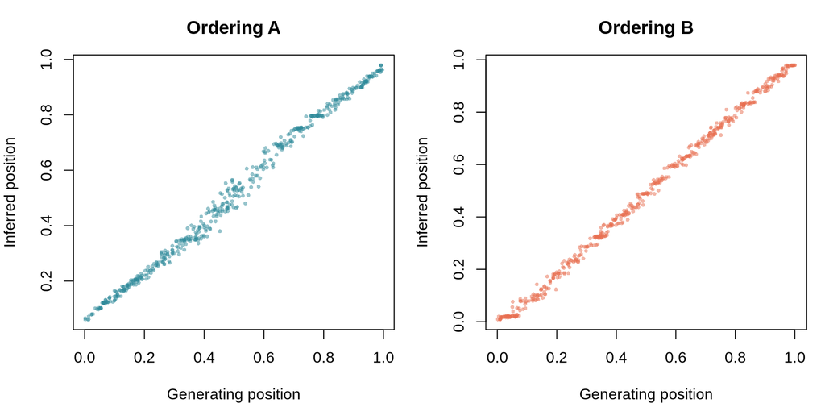

Figure 2. True versus inferred sample position for each aligned ordering. Reversing an axis leaves its ordering unchanged.

## Structural objective

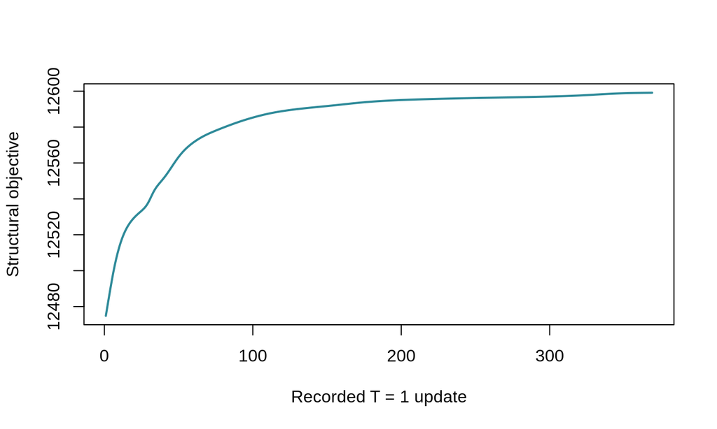

Figure 3. Structural variational objective within the final temperature-one phase.

The structural objective increases during the final $T=1$ refinement phase (Figure 3). The fit converges after **369 recorded temperature-one objective values** under the normalized per-observation rule.

## Reproduce

Run the [experiment script](https://github.com/AgueroZZ/InferOrder/blob/master/experiments/mpcurve_v034_site/run_simulations.R) from the InferOrder root with MPCurver 0.3.4. The [saved results](https://github.com/AgueroZZ/InferOrder/tree/master/experiments/mpcurve_v034_site/results/simulations) include the generating truth, fitted model, and assignment probabilities. This is one simulated data set.